# Smoothing out the Noise

Fred Kaesmann

5/23/2020

```r
library(FredsVietorisRips)
Load_FVR_Dependendencies()
Source_FVR_py(notebook = TRUE)
```

We begin with a set of points, $\mathbb{X}$, and we would like to determine the number of holes present via persistent homology.

```r
##### Import Data ####
df_original <- read.csv("../data/Clark_Sample_data.csv", col.names = c("x", "y"))
```

```r
##### Trials and Samples ####
# How many points are we sampling
#   and how many times are we sampling
sample_size <- 1000
ntrials <- 7

##### Size and Overlap of Pullback Covers ####
# What is the length of our pullback cover
#    and what is the overlap between them?
resolution <- 0.05
gain <- 0.75

##### Connection Distance and Cluster Requirements ####
# Points within distance epsilon are connected
#   and  only points with a minimum number of
#   connections are considered valid clusters
epsilon <- 0.1
min_connections <- 3

##### Number of Components per Cover per Trial ####
ncomponents <- vector("list", length = ntrials)
```

We run 7 iterations where we sample 1000 points from our original point cloud. Each cover beginning at 0 has resolution, or length, 0.05 and they overlap 75%. As we move up the $y$-axis we allocate to each cover the points
$$\begin{equation*}
\text{Cover}_j = \{(x_i, y_i) | y_i \in [y_j, y_j + r)\}
\end{equation*}$$
where $y_j$ is the lower bound of our cover, and $y_j + r$ is its upper bound.

When we run each trial we process the data as normal, the only difference is that we create a list of list which contains the number of components in each cover for each of our trials. We use this list of lists to determine the average number of components in each cover and plot that.

```r
for (trial in c(1:ntrials)) {
  ##### Sample Original Data ####
  df <- df_original %>%
    sample_n(sample_size)

  # Make it compatible with Pyton, start with zero
  rownames(df) <- as.numeric(rownames(df)) - 1

  ##### Filter ####
  list_of_covers <- PullBackCovers(df$x, df$y, resolution, gain)

  ##### How many components do we have? #####
  components <- FindComponents(list_of_covers, epsilon, min_connections, notebook = TRUE)

  ##### nComponents per Cover per Trial ####
  ncomponents[[trial]] <- components %>%
    lapply(length) %>%
    unlist()
}
```

```r
##### Matrix of Trial Results ####
trialMatrix <- matrix(unlist(ncomponents),
                   ncol = ntrials)
dimnames(trialMatrix) <- list(
  paste("Cover", c(1:nrow(trialMatrix))),
  paste("Trial", c(1:ntrials))
)

##### Average Components by Cover ####
averageComponents <- trialMatrix %>%
  rowSums() / ntrials
```

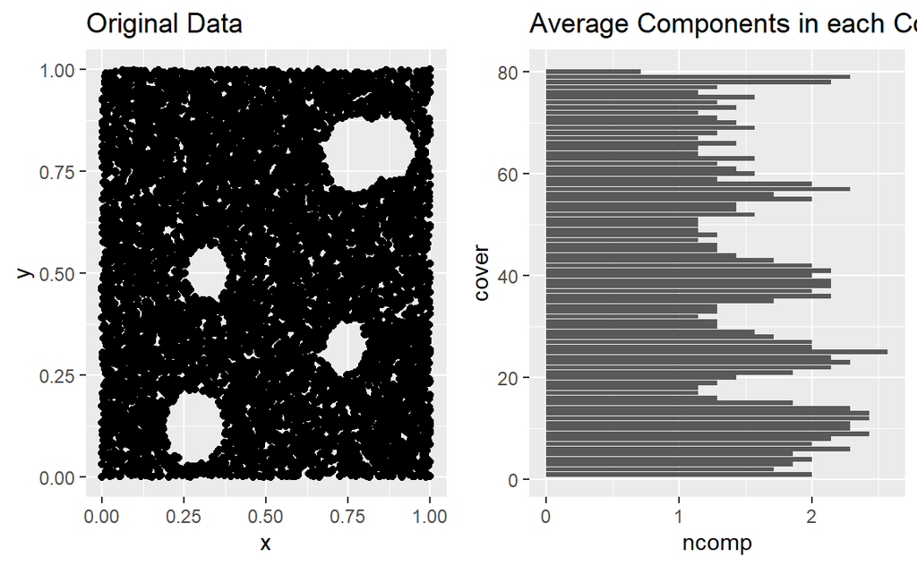

Our above bar chart shows that our initial conditions appear to be well chosen to represent our specific data. This is not the case for what appears to be even minor changes in those initial conditions.

```r
##### Constant Conditions ####
sample_size <- 750
ntrials <- 3
min_connections <- 3
epsilon <- 0.1



##### Varrying Condidtions
resolutionSet <- c(0.25, 0.2, 0.15, 0.1, 0.05, 0.025)
gainSet <- c(0.5, 0.75)

##### Number of Components per Cover per Trial ####
ncomponents <- vector("list", length = ntrials)
```

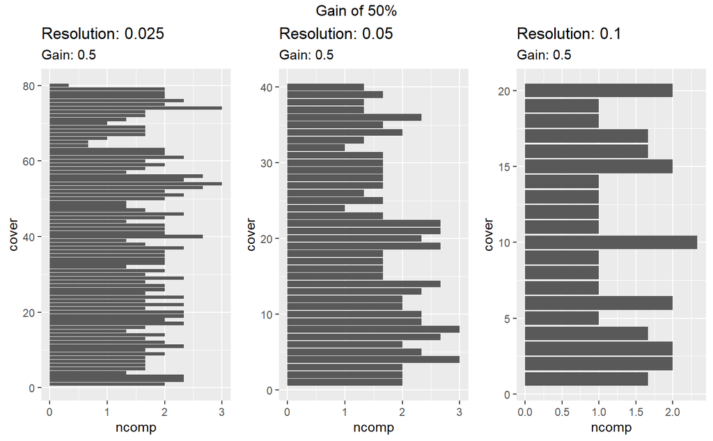

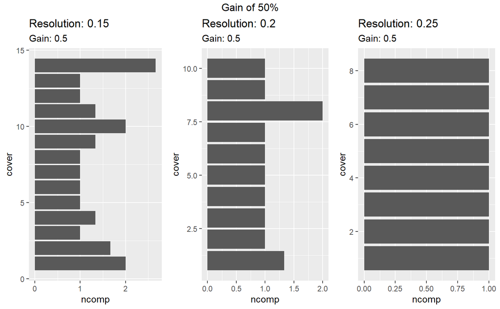

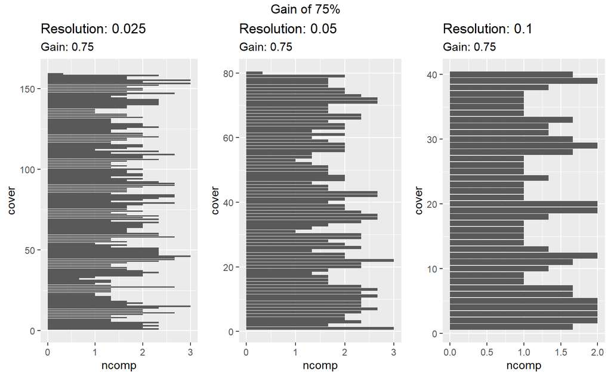

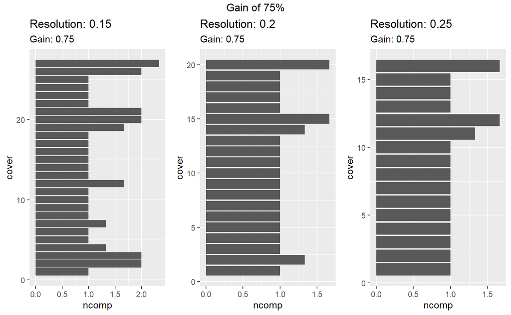

```r
for (resolution in resolutionSet) {
  for (gain in gainSet) {
    for (trial in c(1:ntrials)) {
      ##### Sample Original Data ####
      df <- df_original %>%
        sample_n(sample_size)

      # Make it compatible with Pyton, start with zero
      rownames(df) <- as.numeric(rownames(df)) - 1

      ##### Filter ####
      list_of_covers <- PullBackCovers(df$x, df$y, resolution, gain)

      ##### How many components do we have? #####
      components <- FindComponents(list_of_covers, epsilon, min_connections, notebook = TRUE)

      ##### nComponents per Cover per Trial ####
      ncomponents[[trial]] <- components %>%
        lapply(length) %>%
        unlist()
    }
    ##### Matrix of Trial Results ####
    trialMatrix <- matrix(unlist(ncomponents),
                   ncol = ntrials)
    ##### Average Components by Cover ####
    averageComponents <- trialMatrix %>%
    rowSums() / ntrials

    ##### Create a Chart for each Resolution and Gain Pair ####
    chart <- data.frame(
      cover = c(1:nrow(trialMatrix)),
      ncomp = averageComponents) %>%
      ggplot(aes(x = cover,
                 y = ncomp)) +
      geom_col() +
      coord_flip() +
      ggtitle(paste("Resolution:", resolution),
              paste("Gain:", gain))

    ##### Name each chart cx.xxy.yy ####
    assign(paste0("c", resolution,gain), chart)
  }
}
```